# Import Libraries

```python
import pandas as pd
import numpy as np
import seaborn as sns
import matplotlib.pyplot as plt
%matplotlib inline
import pickle
import imblearn
from imblearn.over_sampling import SMOTE
from time import time
from sklearn.metrics import accuracy_score, average_precision_score, f1_score
from sklearn.model_selection import GridSearchCV
from sklearn.model_selection import KFold


import warnings
warnings.filterwarnings("ignore")

from sklearn.preprocessing import LabelEncoder
encoder=LabelEncoder()
```

# Read Dataset

```python
train=pd.read_csv('fraudTrain.csv')
test=pd.read_csv('fraudTest.csv')

pd.set_option('display.max_columns', None)
pd.set_option('display.max_rows', None)
```

```python
train.head(3)
```

|  | Unnamed: 0 | trans_date_trans_time | cc_num | merchant | category | amt | first | last | gender | street | city | state | zip | lat | long | city_pop | job | dob | trans_num | unix_time | merch_lat | merch_long | is_fraud |
| --- | --- | --- | --- | --- | --- | --- | --- | --- | --- | --- | --- | --- | --- | --- | --- | --- | --- | --- | --- | --- | --- | --- | --- |
| 0 | 0 | 2019-01-01 00:00:18 | 2703186189652095 | fraud_Rippin, Kub and Mann | misc_net | 4.97 | Jennifer | Banks | F | 561 Perry Cove | Moravian Falls | NC | 28654 | 36.0788 | -81.1781 | 3495 | Psychologist, counselling | 1988-03-09 | 0b242abb623afc578575680df30655b9 | 1325376018 | 36.011293 | -82.048315 | 0 |
| 1 | 1 | 2019-01-01 00:00:44 | 630423337322 | fraud_Heller, Gutmann and Zieme | grocery_pos | 107.23 | Stephanie | Gill | F | 43039 Riley Greens Suite 393 | Orient | WA | 99160 | 48.8878 | -118.2105 | 149 | Special educational needs teacher | 1978-06-21 | 1f76529f8574734946361c461b024d99 | 1325376044 | 49.159047 | -118.186462 | 0 |
| 2 | 2 | 2019-01-01 00:00:51 | 38859492057661 | fraud_Lind-Buckridge | entertainment | 220.11 | Edward | Sanchez | M | 594 White Dale Suite 530 | Malad City | ID | 83252 | 42.1808 | -112.2620 | 4154 | Nature conservation officer | 1962-01-19 | a1a22d70485983eac12b5b88dad1cf95 | 1325376051 | 43.150704 | -112.154481 | 0 |

```python
test.head(3)
```

|  | Unnamed: 0 | trans_date_trans_time | cc_num | merchant | category | amt | first | last | gender | street | city | state | zip | lat | long | city_pop | job | dob | trans_num | unix_time | merch_lat | merch_long | is_fraud |
| --- | --- | --- | --- | --- | --- | --- | --- | --- | --- | --- | --- | --- | --- | --- | --- | --- | --- | --- | --- | --- | --- | --- | --- |
| 0 | 0 | 2020-06-21 12:14:25 | 2291163933867244 | fraud_Kirlin and Sons | personal_care | 2.86 | Jeff | Elliott | M | 351 Darlene Green | Columbia | SC | 29209 | 33.9659 | -80.9355 | 333497 | Mechanical engineer | 1968-03-19 | 2da90c7d74bd46a0caf3777415b3ebd3 | 1371816865 | 33.986391 | -81.200714 | 0 |
| 1 | 1 | 2020-06-21 12:14:33 | 3573030041201292 | fraud_Sporer-Keebler | personal_care | 29.84 | Joanne | Williams | F | 3638 Marsh Union | Altonah | UT | 84002 | 40.3207 | -110.4360 | 302 | Sales professional, IT | 1990-01-17 | 324cc204407e99f51b0d6ca0055005e7 | 1371816873 | 39.450498 | -109.960431 | 0 |
| 2 | 2 | 2020-06-21 12:14:53 | 3598215285024754 | fraud_Swaniawski, Nitzsche and Welch | health_fitness | 41.28 | Ashley | Lopez | F | 9333 Valentine Point | Bellmore | NY | 11710 | 40.6729 | -73.5365 | 34496 | Librarian, public | 1970-10-21 | c81755dbbbea9d5c77f094348a7579be | 1371816893 | 40.495810 | -74.196111 | 0 |

```python
display('Train data shape: ', train.shape)
display('Test data shape: ', test.shape)
```

```
'Train data shape: '
```

```
(1296675, 23)
```

```
'Test data shape: '
```

```
(555719, 23)
```

# User Defined Function

## Unnecessary feature drop

```python
def feature_drop(df):
    feature_list = pickle.load(open('unnecessary_features.pkl', 'rb'))
    df.drop(feature_list, inplace=True, axis=1)
    return df
```

## Encoding categorical features

```python
def encode_categorical_feature(dataframe, obj_column):
    for i in obj_column:
        dataframe[i]=encoder.fit_transform(dataframe[i])

    return dataframe
```

## Scalling the data

```python
def scale_data(x):
    inp=str(input("press train for TRAIN data. Press test for TEST data").upper())
    if inp=="TRAIN":
         #Import scale object
        from sklearn.preprocessing import RobustScaler
        scale=RobustScaler()

        #Creating scale object as per dataset and saving it for test
        df=scale.fit(x)
        pickle.dump(scale, open('scaler.pkl', 'wb'))
        Scaler = pickle.load(open('scaler.pkl', 'rb'))
        x_scaled=Scaler.transform(x)


    if inp=="TEST":
        Scaler = pickle.load(open('scaler.pkl', 'rb'))
        x_scaled=Scaler.transform(x)




    robust_df = pd.DataFrame(x_scaled, columns=x.columns)
    return robust_df
```

## Model Evaluation function

```python
def model_evaluate(y_test,y_pred):
    accuracy=accuracy_score(y_test, y_pred)
    F1_score=f1_score(y_test, y_pred, average=None)
    print('Accuracy is {}'.format(round(accuracy, 3)))
    print('F1 score is:', round(F1_score.mean(), 3))
```

# Basic Exploration

## Train Feature and Test Feature Comparison

```python
train_feature=list(train.columns)
test_feature=list(test.columns)

if train_feature==test_feature:
    print("Train and Test data features are same")
else:
    print("Train and Test data features are different")
```

```
Train and Test data features are same
```

## Finding total number of category in output feature

```python
train['is_fraud'].value_counts()
```

```
is_fraud
0    1289169
1       7506
Name: count, dtype: int64
```

In train data, the fraud transaction is too less to train a model i.e. model will overfit for Non Fraud Transaction.  
But in test data we do not need the 'is_fraud' feature.

```python
test.drop(['is_fraud'], inplace=True, axis=1)
test.head(2)
```

|  | Unnamed: 0 | trans_date_trans_time | cc_num | merchant | category | amt | first | last | gender | street | city | state | zip | lat | long | city_pop | job | dob | trans_num | unix_time | merch_lat | merch_long |
| --- | --- | --- | --- | --- | --- | --- | --- | --- | --- | --- | --- | --- | --- | --- | --- | --- | --- | --- | --- | --- | --- | --- |
| 0 | 0 | 2020-06-21 12:14:25 | 2291163933867244 | fraud_Kirlin and Sons | personal_care | 2.86 | Jeff | Elliott | M | 351 Darlene Green | Columbia | SC | 29209 | 33.9659 | -80.9355 | 333497 | Mechanical engineer | 1968-03-19 | 2da90c7d74bd46a0caf3777415b3ebd3 | 1371816865 | 33.986391 | -81.200714 |
| 1 | 1 | 2020-06-21 12:14:33 | 3573030041201292 | fraud_Sporer-Keebler | personal_care | 29.84 | Joanne | Williams | F | 3638 Marsh Union | Altonah | UT | 84002 | 40.3207 | -110.4360 | 302 | Sales professional, IT | 1990-01-17 | 324cc204407e99f51b0d6ca0055005e7 | 1371816873 | 39.450498 | -109.960431 |

```python
train.describe().T
```

|  | count | mean | std | min | 25% | 50% | 75% | max |
| --- | --- | --- | --- | --- | --- | --- | --- | --- |
| Unnamed: 0 | 1296675.0 | 6.483370e+05 | 3.743180e+05 | 0.000000e+00 | 3.241685e+05 | 6.483370e+05 | 9.725055e+05 | 1.296674e+06 |
| cc_num | 1296675.0 | 4.171920e+17 | 1.308806e+18 | 6.041621e+10 | 1.800429e+14 | 3.521417e+15 | 4.642255e+15 | 4.992346e+18 |
| amt | 1296675.0 | 7.035104e+01 | 1.603160e+02 | 1.000000e+00 | 9.650000e+00 | 4.752000e+01 | 8.314000e+01 | 2.894890e+04 |
| zip | 1296675.0 | 4.880067e+04 | 2.689322e+04 | 1.257000e+03 | 2.623700e+04 | 4.817400e+04 | 7.204200e+04 | 9.978300e+04 |
| lat | 1296675.0 | 3.853762e+01 | 5.075808e+00 | 2.002710e+01 | 3.462050e+01 | 3.935430e+01 | 4.194040e+01 | 6.669330e+01 |
| long | 1296675.0 | -9.022634e+01 | 1.375908e+01 | -1.656723e+02 | -9.679800e+01 | -8.747690e+01 | -8.015800e+01 | -6.795030e+01 |
| city_pop | 1296675.0 | 8.882444e+04 | 3.019564e+05 | 2.300000e+01 | 7.430000e+02 | 2.456000e+03 | 2.032800e+04 | 2.906700e+06 |
| unix_time | 1296675.0 | 1.349244e+09 | 1.284128e+07 | 1.325376e+09 | 1.338751e+09 | 1.349250e+09 | 1.359385e+09 | 1.371817e+09 |
| merch_lat | 1296675.0 | 3.853734e+01 | 5.109788e+00 | 1.902779e+01 | 3.473357e+01 | 3.936568e+01 | 4.195716e+01 | 6.751027e+01 |
| merch_long | 1296675.0 | -9.022646e+01 | 1.377109e+01 | -1.666712e+02 | -9.689728e+01 | -8.743839e+01 | -8.023680e+01 | -6.695090e+01 |
| is_fraud | 1296675.0 | 5.788652e-03 | 7.586269e-02 | 0.000000e+00 | 0.000000e+00 | 0.000000e+00 | 0.000000e+00 | 1.000000e+00 |

# Data Cleaning

## Null Value

```python
train.isnull().sum()
```

```
Unnamed: 0               0
trans_date_trans_time    0
cc_num                   0
merchant                 0
category                 0
amt                      0
first                    0
last                     0
gender                   0
street                   0
city                     0
state                    0
zip                      0
lat                      0
long                     0
city_pop                 0
job                      0
dob                      0
trans_num                0
unix_time                0
merch_lat                0
merch_long               0
is_fraud                 0
dtype: int64
```

```python
test.isnull().sum()
```

```
Unnamed: 0               0
trans_date_trans_time    0
cc_num                   0
merchant                 0
category                 0
amt                      0
first                    0
last                     0
gender                   0
street                   0
city                     0
state                    0
zip                      0
lat                      0
long                     0
city_pop                 0
job                      0
dob                      0
trans_num                0
unix_time                0
merch_lat                0
merch_long               0
dtype: int64
```

We do not have any null value in out train and test data set.

## Drop Unnecessary features

```python
train.head(3)
```

|  | Unnamed: 0 | trans_date_trans_time | cc_num | merchant | category | amt | first | last | gender | street | city | state | zip | lat | long | city_pop | job | dob | trans_num | unix_time | merch_lat | merch_long | is_fraud |
| --- | --- | --- | --- | --- | --- | --- | --- | --- | --- | --- | --- | --- | --- | --- | --- | --- | --- | --- | --- | --- | --- | --- | --- |
| 0 | 0 | 2019-01-01 00:00:18 | 2703186189652095 | fraud_Rippin, Kub and Mann | misc_net | 4.97 | Jennifer | Banks | F | 561 Perry Cove | Moravian Falls | NC | 28654 | 36.0788 | -81.1781 | 3495 | Psychologist, counselling | 1988-03-09 | 0b242abb623afc578575680df30655b9 | 1325376018 | 36.011293 | -82.048315 | 0 |
| 1 | 1 | 2019-01-01 00:00:44 | 630423337322 | fraud_Heller, Gutmann and Zieme | grocery_pos | 107.23 | Stephanie | Gill | F | 43039 Riley Greens Suite 393 | Orient | WA | 99160 | 48.8878 | -118.2105 | 149 | Special educational needs teacher | 1978-06-21 | 1f76529f8574734946361c461b024d99 | 1325376044 | 49.159047 | -118.186462 | 0 |
| 2 | 2 | 2019-01-01 00:00:51 | 38859492057661 | fraud_Lind-Buckridge | entertainment | 220.11 | Edward | Sanchez | M | 594 White Dale Suite 530 | Malad City | ID | 83252 | 42.1808 | -112.2620 | 4154 | Nature conservation officer | 1962-01-19 | a1a22d70485983eac12b5b88dad1cf95 | 1325376051 | 43.150704 | -112.154481 | 0 |

```python
unnecessary_features=['Unnamed: 0','cc_num','merchant','first','last','street','zip','trans_date_trans_time',
                      'dob','trans_num','unix_time','merch_lat','merch_long']

pickle.dump(unnecessary_features, open('unnecessary_features.pkl', 'wb'))
```

```python
train=feature_drop(train)
```

## Splitting into Input and Output feature

```python
x=train.drop(['is_fraud'], inplace=False, axis=1)
y=train['is_fraud']
```

```python
x.head(3)
```

|  | category | amt | gender | city | state | lat | long | city_pop | job |
| --- | --- | --- | --- | --- | --- | --- | --- | --- | --- |
| 0 | misc_net | 4.97 | F | Moravian Falls | NC | 36.0788 | -81.1781 | 3495 | Psychologist, counselling |
| 1 | grocery_pos | 107.23 | F | Orient | WA | 48.8878 | -118.2105 | 149 | Special educational needs teacher |
| 2 | entertainment | 220.11 | M | Malad City | ID | 42.1808 | -112.2620 | 4154 | Nature conservation officer |

```python
y.head(3)
```

```
0    0
1    0
2    0
Name: is_fraud, dtype: int64
```

## Seperate Numerical and Categorical features

```python
column_int=[]
column_obj=[]
for col in x:
    dataTypeObj = x.dtypes[col]
    if dataTypeObj == np.int64 or dataTypeObj == np.float64 :
        column_int.append(col)
    if dataTypeObj== object:
        column_obj.append(col)
```

```python
display("Numerical features:", column_int)
display("-"*80)
display("Categorical features:", column_obj)
```

```
'Numerical features:'
```

```
['amt', 'lat', 'long', 'city_pop']
```

```
'--------------------------------------------------------------------------------'
```

```
'Categorical features:'
```

```
['category', 'gender', 'city', 'state', 'job']
```

## Cheque for irregularities in categorical features

```python
for i in column_obj:
    print("_"*50)
    print("Column name:", i)
    display(x[i].value_counts())
    print("_"*50)
```

```
__________________________________________________
Column name: category
```

```
category
gas_transport     131659
grocery_pos       123638
home              123115
shopping_pos      116672
kids_pets         113035
shopping_net       97543
entertainment      94014
food_dining        91461
personal_care      90758
health_fitness     85879
misc_pos           79655
misc_net           63287
grocery_net        45452
travel             40507
Name: count, dtype: int64
```

```
__________________________________________________
__________________________________________________
Column name: gender
```

```
gender
F    709863
M    586812
Name: count, dtype: int64
```

```
__________________________________________________
__________________________________________________
Column name: city
```

```
city
Birmingham                   5617
San Antonio                  5130
Utica                        5105
Phoenix                      5075
Meridian                     5060
Thomas                       4634
Conway                       4613
Cleveland                    4604
Warren                       4599
Houston                      4168
Burbank                      4159
Naples                       4155
Arcadia                      4096
Indianapolis                 4073
Brandon                      4044
Fulton                       3977
Lahoma                       3646
Allentown                    3639
Lakeland                     3635
Dallas                       3629
Washington                   3613
Andrews                      3599
Detroit                      3584
Huntsville                   3560
Hudson                       3547
Orient                       3545
Fort Washakie                3527
Philadelphia                 3517
Uledi                        3123
Elberta                      3123
Superior                     3119
Bradley                      3117
Moorhead                     3113
Hinesburg                    3112
Wilmington                   3110
Hinckley                     3110
Bowdoin                      3107
De Witt                      3106
Morrisdale                   3105
```

[output cut: 841 more lines]

```
Noblesville                     8
Las Vegas                       8
Buellton                        8
Crouse                          8
Irvington                       8
Pleasant Hill                   8
Wappapello                      8
Norfolk                         7
Streator                        7
Vacaville                       7
Claypool                        7
Karns City                      7
Bruce                           7
Chattanooga                     7
Name: count, dtype: int64
```

```
__________________________________________________
__________________________________________________
Column name: state
```

```
state
TX    94876
NY    83501
PA    79847
CA    56360
OH    46480
MI    46154
IL    43252
FL    42671
AL    40989
MO    38403
MN    31714
AR    31127
NC    30266
WI    29368
VA    29250
SC    29190
KY    28475
IN    27580
IA    26985
OK    26671
MD    26193
GA    26063
WV    25691
NJ    24603
NE    24168
KS    22996
MS    21188
LA    20965
WY    19322
WA    18924
OR    18597
TN    17554
ME    16505
NM    16407
ND    14786
CO    13880
MA    12376
SD    12324
VT    11768
MT    11754
AZ    10770
UT    10699
NH     8278
CT     7702
NV     5607
ID     5545
DC     3613
HI     2559
AK     2120
RI      550
DE        9
Name: count, dtype: int64
```

```
__________________________________________________
__________________________________________________
Column name: job
```

```
job
Film/video editor                                              9779
Exhibition designer                                            9199
Naval architect                                                8684
Surveyor, land/geomatics                                       8680
Materials engineer                                             8270
Designer, ceramics/pottery                                     8225
Systems developer                                              7700
IT trainer                                                     7679
Financial adviser                                              7659
Environmental consultant                                       7547
Chartered public finance accountant                            7210
Scientist, audiological                                        7174
Chief Executive Officer                                        7172
Copywriter, advertising                                        7146
Comptroller                                                    6730
Sub                                                            6701
Podiatrist                                                     6653
Agricultural consultant                                        6642
Paramedic                                                      6635
Magazine features editor                                       6602
Historic buildings inspector/conservation officer              6205
Librarian, public                                              6186
Building surveyor                                              6178
Musician                                                       6178
Water engineer                                                 6164
Scientist, research (maths)                                    6159
Mining engineer                                                6151
Barrister                                                      6127
Audiological scientist                                         6118
Immunologist                                                   6085
Clothing/textile technologist                                  6049
Prison officer                                                 5701
Financial trader                                               5693
Claims inspector/assessor                                      5668
Energy engineer                                                5668
Petroleum engineer                                             5667
Quantity surveyor                                              5646
Make                                                           5643
Engineer, automotive                                           5634
```

[output cut: 441 more lines]

```
Personnel officer                                                12
Engineer, site                                                   12
Solicitor                                                        11
Homeopath                                                        11
Accountant, chartered                                            11
Industrial buyer                                                 10
Broadcast journalist                                              9
Forest/woodland manager                                           9
Armed forces technical officer                                    8
Information officer                                               8
Veterinary surgeon                                                8
Ship broker                                                       7
Contracting civil engineer                                        7
Warehouse manager                                                 7
Name: count, dtype: int64
```

```
__________________________________________________
```

## Cheque for outliers

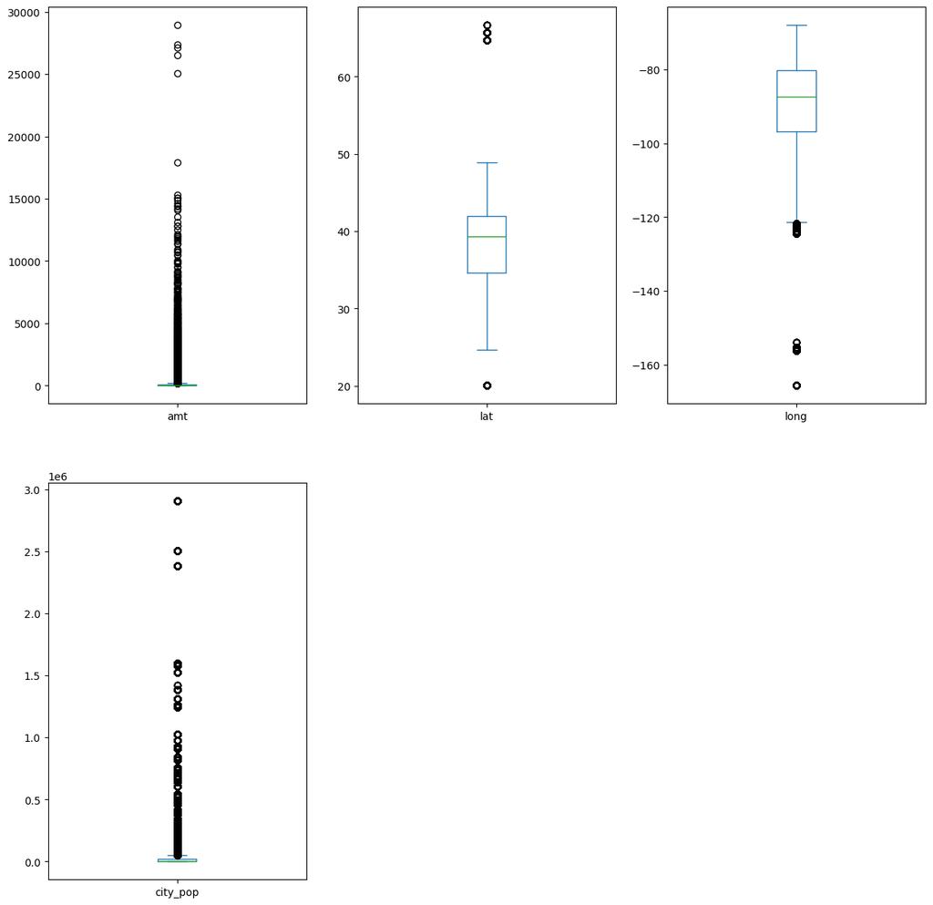

```python
x.plot(kind="box", subplots=True, layout=(2,3), figsize=(15,15));
```

So we have huge ammount of outliers in **amt** , **lat** , **long** and **city_pop** >br> But from those features, lat and long are geographical data so we can not treat them as outliers and city population and amt also can not be treated as outliers.

# Exploratory Data Analysis

```python
x.head()
```

|  | category | amt | gender | city | state | lat | long | city_pop | job |
| --- | --- | --- | --- | --- | --- | --- | --- | --- | --- |
| 0 | misc_net | 4.97 | F | Moravian Falls | NC | 36.0788 | -81.1781 | 3495 | Psychologist, counselling |
| 1 | grocery_pos | 107.23 | F | Orient | WA | 48.8878 | -118.2105 | 149 | Special educational needs teacher |
| 2 | entertainment | 220.11 | M | Malad City | ID | 42.1808 | -112.2620 | 4154 | Nature conservation officer |
| 3 | gas_transport | 45.00 | M | Boulder | MT | 46.2306 | -112.1138 | 1939 | Patent attorney |
| 4 | misc_pos | 41.96 | M | Doe Hill | VA | 38.4207 | -79.4629 | 99 | Dance movement psychotherapist |

## Visualising fraud and non fraud transactions

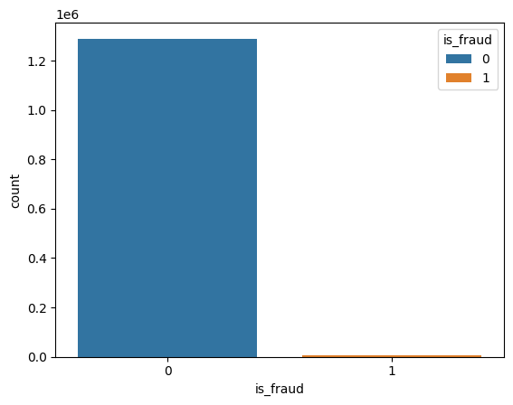

```python
sns.countplot(x="is_fraud", data=train, hue="is_fraud")
```

So in this data set we have huge ammount of non fraud transactions which can lead our model to overfitting to non fraud transaction.

## Amount to difference between fraud and non-fraud transaction

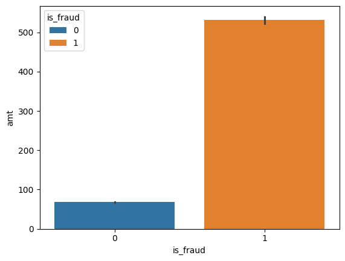

```python
sns.barplot(x="is_fraud", y="amt",hue="is_fraud",data=train)
```

## Location of fraud and non fraud transaction

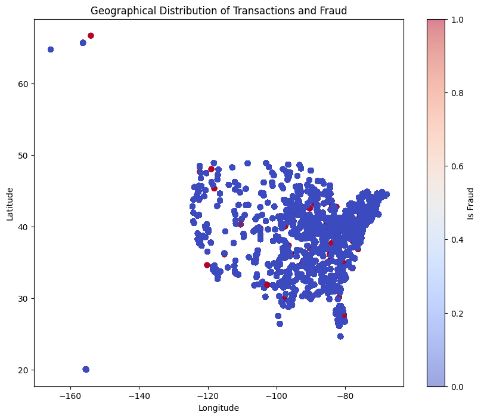

```python
plt.figure(figsize=(10, 8))
plt.scatter(train['long'], train['lat'], c=train['is_fraud'], cmap='coolwarm', alpha=0.5)
plt.title('Geographical Distribution of Transactions and Fraud')
plt.xlabel('Longitude')
plt.ylabel('Latitude')
plt.colorbar(label='Is Fraud')
plt.show()
```

## Fraud and non fraud transactions in various category

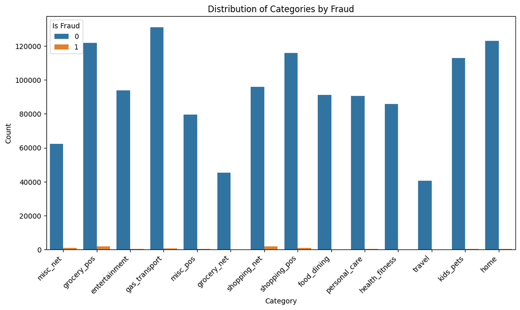

```python
plt.figure(figsize=(12, 6))
sns.countplot(x='category', hue='is_fraud', data=train)
plt.title('Distribution of Categories by Fraud')
plt.xlabel('Category')
plt.ylabel('Count')
plt.xticks(rotation=45, ha="right")
plt.legend(title='Is Fraud')
plt.show()
```

most of fraud transactions are happend in **misc_net** , **grocery_pos** , **shopping net** , **shopping_pos**

## City vs Fraud

```python
df_city = train[train['is_fraud'] == 1].groupby('city')['is_fraud'].count()
top_20_city= df_city.sort_values(ascending=False).head(20)
top_20_city
```

```
city
Houston          39
Warren           33
Naples           29
Huntsville       29
Topeka           27
Tulsa            27
Dallas           27
Detroit          26
Randolph         25
Utica            25
San Antonio      25
Albuquerque      24
Beaver Falls     24
Clearwater       24
New York City    23
Aurora           23
Bay City         22
Hudson           21
Lakeland         21
Fenelton         21
Name: is_fraud, dtype: int64
```

## Job vs Fraud

```python
df_job = train[train['is_fraud'] == 1].groupby('job')['is_fraud'].count()
top_20_job= df_job.sort_values(ascending=False).head(20)
top_20_job
```

```
job
Materials engineer                       62
Trading standards officer                56
Naval architect                          53
Exhibition designer                      51
Surveyor, land/geomatics                 50
Mechanical engineer                      49
Prison officer                           48
Quantity surveyor                        48
Audiological scientist                   46
Senior tax professional/tax inspector    45
Copywriter, advertising                  45
Film/video editor                        44
Scientist, biomedical                    44
Financial trader                         43
Television production assistant          42
Podiatrist                               41
Buyer, industrial                        41
Private music teacher                    41
Nurse, children's                        40
Magazine features editor                 40
Name: is_fraud, dtype: int64
```

## City Population vs Fraud

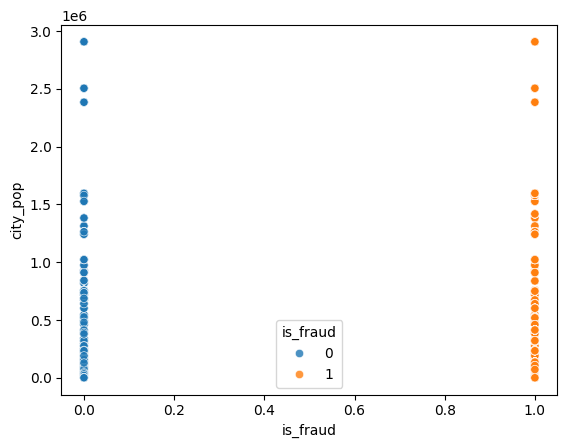

```python
sns.scatterplot(data=train, x="is_fraud",y="city_pop", hue="is_fraud", alpha=0.8);
```

# Feature Selection

## Encode Categorical Features

```python
x=encode_categorical_feature(x, column_obj)
x.head()
```

|  | category | amt | gender | city | state | lat | long | city_pop | job |
| --- | --- | --- | --- | --- | --- | --- | --- | --- | --- |
| 0 | 8 | 4.97 | 0 | 526 | 27 | 36.0788 | -81.1781 | 3495 | 370 |
| 1 | 4 | 107.23 | 0 | 612 | 47 | 48.8878 | -118.2105 | 149 | 428 |
| 2 | 0 | 220.11 | 1 | 468 | 13 | 42.1808 | -112.2620 | 4154 | 307 |
| 3 | 2 | 45.00 | 1 | 84 | 26 | 46.2306 | -112.1138 | 1939 | 328 |
| 4 | 9 | 41.96 | 1 | 216 | 45 | 38.4207 | -79.4629 | 99 | 116 |

## Heatmap and correlation

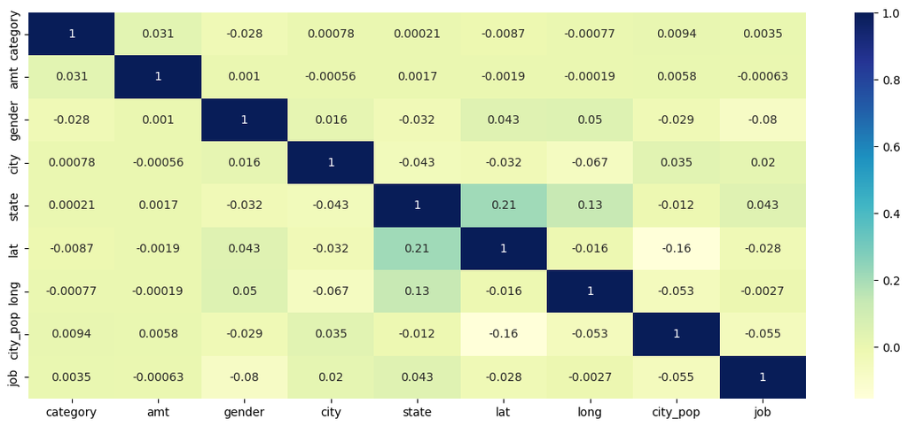

```python
plt.figure(figsize = (15,6))
sns.heatmap(x.corr(), cmap="YlGnBu", annot=True)
plt.show()
```

```
[0.13044954 0.62262104 0.01271339 0.0416238  0.03211138 0.03858255
 0.03836996 0.04106777 0.04246059]
Plotting graph of feature importances for better visualization
```

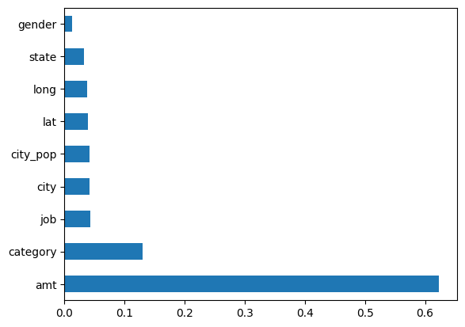

```
______________________________________________________________________
Getting importance of all features in descending order as a dataframe
______________________________________________________________________
```

|  | Features | Importance |
| --- | --- | --- |
| 1 | amt | 0.622621 |
| 0 | category | 0.130450 |
| 8 | job | 0.042461 |
| 3 | city | 0.041624 |
| 7 | city_pop | 0.041068 |
| 5 | lat | 0.038583 |
| 6 | long | 0.038370 |
| 4 | state | 0.032111 |
| 2 | gender | 0.012713 |

```python
from sklearn.ensemble import ExtraTreesRegressor
import matplotlib.pyplot as plt
model = ExtraTreesRegressor()
model.fit(x, y)


print(model.feature_importances_)



#plot graph of feature importances for better visualization
print("Plotting graph of feature importances for better visualization")
feat_importances = pd.Series(model.feature_importances_, index=x.columns)
feat_importances.nlargest(x.shape[1]).plot(kind='barh')
plt.show()

print("_"*70)
#Getting importance of all features in descending order as a dataframe
print("Getting importance of all features in descending order as a dataframe")
print("_"*70)
feat_importances.sort_values(ascending=False)
feature_df=feat_importances.to_frame()
DF=feat_importances.reset_index().rename(columns={"index":"Features", 0:"Importance"})
DF=DF.sort_values(by=['Importance'], ascending=False)
display(DF)
```

From the above dataframe, **amt** is the most important feature which has the most influence in output.

## Data Balance

Since out data set is highly biased toward non fraud transaction so we have to create synthetic data for fraud transaction to get the dataset balanced for all classes.

```python
sm = SMOTE(random_state=42)
X, Y = sm.fit_resample(x, y)
```

```python
Y.value_counts()
```

```
is_fraud
0    1289169
1    1289169
Name: count, dtype: int64
```

We balanced the dataset for all classes using SMOTE.

## Scalling the data

```python
X_scaled=scale_data(X)
```

```python
X_scaled.head()
```

|  | category | amt | gender | city | state | lat | long | city_pop | job |
| --- | --- | --- | --- | --- | --- | --- | --- | --- | --- |
| 0 | 0.166667 | -0.189223 | 0.0 | 0.202673 | -0.045455 | -0.488543 | 0.359010 | 0.049253 | 0.483193 |
| 1 | -0.500000 | 0.036722 | 0.0 | 0.394209 | 0.863636 | 1.411891 | -1.907633 | -0.120294 | 0.726891 |
| 2 | -1.166667 | 0.286133 | 1.0 | 0.073497 | -0.681818 | 0.416793 | -1.543543 | 0.082645 | 0.218487 |
| 3 | -0.833333 | -0.100776 | 1.0 | -0.781737 | -0.090909 | 1.017650 | -1.534472 | -0.029592 | 0.306723 |
| 4 | 0.333333 | -0.107493 | 1.0 | -0.487751 | 0.772727 | -0.141082 | 0.463992 | -0.122827 | -0.584034 |

# Model Building and training

## Train Test Split

```python
from sklearn.model_selection import train_test_split
x_train, x_test, y_train, y_test=train_test_split(X_scaled, Y, train_size=0.70)
print("Shape of X train:",x_train.shape)
print("Shape of Y train:",y_train.shape)
print("Shape of X test:",x_test.shape)
print("Shape of Y test:",y_test.shape)
```

```
Shape of X train: (1804836, 9)
Shape of Y train: (1804836,)
Shape of X test: (773502, 9)
Shape of Y test: (773502,)
```

## Logistic Regression

```python
from sklearn.linear_model import LogisticRegression
lr=LogisticRegression()

# starting execution time
start_time=time()

parameter={"penalty":["l1","l2"],
            "solver" : ['newton-cg', 'lbfgs', 'saga'],
          "max_iter": [100, 1000, 1500],
          "multi_class": ['auto', 'multinomial']
          }
kf=KFold(n_splits=5)
grid_sv = GridSearchCV(lr, cv=kf, param_grid=parameter, scoring='accuracy', n_jobs=-1)
grid_sv.fit(x_train, y_train)
param_dict_lr=dict(grid_sv.best_params_)

LR=LogisticRegression(penalty=param_dict_lr["penalty"],
                         solver=param_dict_lr["solver"],
                         max_iter= param_dict_lr["max_iter"],
                     multi_class= param_dict_lr["multi_class"])
LR.fit(x_train, y_train)
y_pred_LR=LR.predict(x_test)
print("Scores of Logistic Regression:")
model_evaluate(y_test,y_pred_LR)
print("Train Accuracy:",LR.score(x_train, y_train))
print("Test Accuracy:",LR.score(x_test, y_test))
pickle.dump(LR, open('logistic_regressor.pkl', 'wb'))

# ending time of execution
end_time=time()

final_time = (end_time-start_time)/60
# display execution time
print('final execution time is : {} minutes'.format(final_time))
```

```
Scores of Logistic Regression:
Accuracy is 0.853
F1 score is: 0.852
Train Accuracy: 0.8535107899000242
Test Accuracy: 0.8528963079604189
final execution time is : 5.35617595911026 minutes
```

## Decision Tree Classifier

```python
from sklearn.tree import DecisionTreeClassifier
DT=DecisionTreeClassifier()
start_time=time()

parameter={
    "criterion" : ["gini", "entropy"],
    "splitter" : ["best", "random"],
    "max_depth" : [1, 2, 3, 4, 5, 6, 7, 8, 9, 10]
}
kf=KFold(n_splits=5)
grid_sv = GridSearchCV(DT, cv=kf, param_grid=parameter, scoring='accuracy', n_jobs=-1)
grid_sv.fit(x_train, y_train)

parameters=dict(grid_sv.best_params_)





DT=DecisionTreeClassifier(criterion=parameters["criterion"],
                          max_depth=parameters["max_depth"],
                          splitter=parameters["splitter"])
DT.fit(x_train, y_train)
y_pred_DT=DT.predict(x_test)
model_evaluate(y_test,y_pred_DT)


print("Train Accuracy:",np.round(DT.score(x_train, y_train)*100,3),"%")
print("Test Accuracy:",np.round(DT.score(x_test, y_test)*100,3),"%")
pickle.dump(DT, open('Decision_tree.pkl', 'wb'))
# ending time of execution
end_time=time()

final_time = (end_time-start_time)/60
# display execution time
print('final execution time is : {} minutes'.format(final_time))
```

```
Accuracy is 0.937
F1 score is: 0.937
Train Accuracy: 93.754 %
Test Accuracy: 93.709 %
final execution time is : 3.152241762479146 minutes
```

## Random Forest Classifier

```python
from sklearn.ensemble import RandomForestClassifier
rf=RandomForestClassifier()
start_time=time()

parameter={
    "criterion" : ["gini", "entropy", "log_loss"],
    "max_features" : ["sqrt", "log2"],
    "max_depth" : [1, 2, 3, 4, 5, 6, 7, 8, 9, 10]
}
kf=KFold(n_splits=5)
grid_sv = GridSearchCV(rf, cv=kf, param_grid=parameter, scoring='accuracy', n_jobs=-1)
grid_sv.fit(x_train, y_train)

parameters=dict(grid_sv.best_params_)





RF=RandomForestClassifier(criterion=parameters["criterion"],
                          max_depth=parameters["max_depth"],
                          max_features=parameters["max_features"])
RF.fit(x_train, y_train)
y_pred_RF=RF.predict(x_test)
model_evaluate(y_test,y_pred_RF)


print("Train Accuracy:",np.round(RF.score(x_train, y_train)*100,3),"%")
print("Test Accuracy:",np.round(RF.score(x_test, y_test)*100,3),"%")
pickle.dump(RF, open('random_forest.pkl', 'wb'))
# ending time of execution
end_time=time()

final_time = (end_time-start_time)/60
# display execution time
print('final execution time is : {} minutes'.format(final_time))
```

```
Accuracy is 0.933
F1 score is: 0.933
Train Accuracy: 93.322 %
Test Accuracy: 93.282 %
final execution time is : 194.2861731727918 minutes
```